# Fatal Compassion: Mapping the Deadliest Zones for Aid Workers

DSAN Scholarship Competition 2025: Data Visualization Project

Author

jl3205

Published

March 24, 2025

Abstract

This project aims to transform 4,337 humanitarian incident reports into a tactical intelligence brief for operational decision-makers. By analyzing attacks on aid workers from 1997 to 2025 across 75+ countries, it reveals systemic risk disparities, behavioral threat patterns, and predictive signals for future violence. The analysis culminates in a prototype that demonstrates how structured data and machine learning can power real-time risk scoring, early alerts, and strategic field deployment.

> ‼️ **4,337 deadly events. 75+ countries. One goal: protect those who protect others.**<sup>1</sup>

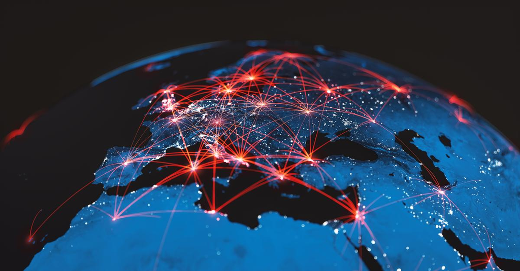

Global Humanitarian Threat Network

Across some of the world’s most fragile regions, humanitarian aid workers — from 1997 to the present — have faced an escalating spectrum of violent threats, ranging from ambushes to abductions. This project transforms raw incident records into a threat - informed intelligence layer to support operational decision - making.

By analyzing thousands of recorded attacks on UN agencies, international NGOs, and Red Cross affiliates, I uncovered patterns in **time**, **geography**, and **modus operandi**. This allows us to identify not only where humanitarian work is most dangerous, but also trace how threat environments shift over time.

The approach is inspired by **real-time situational awareness** platforms commonly used in defense and security contexts<sup>2</sup>. Just as Palantir empowers decision - makers in conflict zones, this project aims to do the same for humanitarian stakeholders — equipping them with **foresight, not just hindsight**<sup>3</sup>.

## References

1.

ChatGPT, version-4o, OpenAI, march-24, 2024, chat.openai.com.

2.

KuRpiewsKa-KoRbut, R. Digital technologies in the global humanitarian sector: A case study of ukraine. *Journal of Modern Science* **60**, 730–743 (2024).

3.

Martin, A. Aidwashing surveillance: Critiquing the corporate exploitation of humanitarian crises. *Surveillance & Society* **21**, 96–102 (2023).